[figure not shown]

# 06 Prove - Assignment

## Objectives

Creating a endless loop video by analysing frames in a video.

**note:** All assignments in this course has always been individual based. Sharing code is an automatic zero for any assignment.

## Project Details

You will be writing a Python program that can create an endless video by analysing the frames from in the video. This process can be a great deal of processing time if you decide to use a long and/or large video file.

#### Candle Images

We are supplying frames of a burning candle. These candle images need to be placed in a sub-folder to where your project code is found. The two frames that match the most were found to be frame 38 and frame 94. You can use the candle images for testing your program. (ie., your program should find frames 38 and 94 to be the best frames or near those frame numbers). Below are these frames.

Image at frame 38

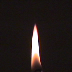

Image at frame 94

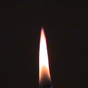

Displaying the comparison array as an image. (We give you a function to display this image). The two frames used in the loop are indicated using circles. The rows and columns are frames and the color in the image indicates how well they compare to each other. Note that the diagonal line from top-left to bottom-right is always set to 0. The whiter the pixel - the less it matched.

In this image, the frames 38 and 94 match the most and are the farthest apart of each other.

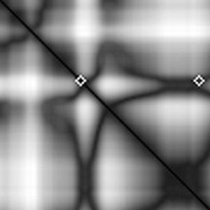

**"match the most and are the farthest apart"**

Obviously, frame N and frame N+1 are going to be very simiular to each other. However, they are not far enough apart to make a good endless loop final video. It is up to you to decide how these two frames are found.

## Instructions

- Download `project.py` from Github folder `week06/assignment`.
- Download `project.docx` from Github folder `week06/assignment`. You will be filling out this document for your project and submitting it with your Python code.
- Download the `candles.zip` file if you need any images for testing your code.
- Implement the main() function found in `project.py`. You are free to create any functions that will help you.
- You are only allowed to use the Python packages: Numpy and OpenCV.
- You **must** use your program with your own personal video.
  - Be carefull not to record something too long or is too large (ie., width x height). You are free to resize and/or reduce the number of frames so you can work with something more manageable.
  - You must create this video where a loop could be found.
- Fill out the `project.docx` document with your project results.

#### Final Video

- Once you have found the loop frames, create a new color video that contains 4 loops from the original video.
- When looping from the end to the start frame, you must add new frames that are contructed from the start/end frames. This can be a blend between them or what ever you feel is the best transition. You can decide on the number of new frames to create and use in your final video.
- You will **not** be sumitting your video in Canvas. You will need to host you video at DropBox, OneDrive, GDrive, YouTube.com, etc... and submit a link to that video.

Suggestions:

- Get your project code to work with the sample candle images. You should be able to find the same start and end frames for the loop (or close to it) and be able to create the same results as outlined in this document.
- Do you processing and comparing of the images using grayscale images. The final looping video needs to be in color.
- You will be able to process the frames of your video faster if you load them all into a list. However, depending on the number of the frames and their size, you might run out of memory doing this.
- The function write_diff_matrix() will be called at the end of your program once.
- The function image_compare() requires grayscale images.

## Rubric

| Task | Points |
| --- | --- |
| Compare frames correctly | 10 |
| Find loop in video and explanation in project document | 20 |
| Creation of comparison image | 10 |
| Creation of 4 loop video | 50 |
| implemented good blend transition between each loop in final video | 10 |
| ------ | ----- |
| Total | 100 |

## Submission

1. Upload your project Python code file.
2. Upload you project document with your answers for this project.
3. **Do not** upload any video files.